# ML_2_Summary

Study Crew

3/9/2021

# Machine Learning 2 Summary Document

This document is a comprehensive summary for Machine Learning 2. It is intended to help us study for the exams and for future reference in our professional lives (if any companies actually use R).

## Basic Statistics

Authors: Carrington Metts & Thomas Trankle

### Bias/Variance Tradeoff

**Variance** is defined as the amount by which a prediction would vary if it were estimated with a different training set. A model with high variance is *overfit*- small changes in the training set may result in large changes to the model.

**Bias** is defined as the amount of error that is due to reducing a complex real-world dataset to a simple model. A model with high bias is *underfit*- changes in the training set are unlikely to significantly change the model, but the model still does not make good predictions for the data.

If your training error is low and test error is high, the model has *high variance*. If both the training and testing errors are high, the model has *high bias*. If both the training and testing errors are low, the model has *low variance and low bias*.

### Law of Parsimony

- Occam’s razor
- Simpler Model is always better than complex model
- Only keep features that truly add substance to the model
- Avoid **overfitting** the model
  - Unimportant/irrelevant features overcomplicate model
  - Highly correlated features overcomplicate model (multicollinearity)
  - Interaction terms, polynomial terms, interaction with polynomials, etc.  models get complicated very quickly!

### Stats Formula’s

Training set MSE = an underestimate of test MSE

MSE = RSS /n

Least squares method minimizes training not testing MSE

We can estimate test error indirectly by adjusting training error:

- $C_{P} = \frac{1}{n}(RSS + 2d\hat{\sigma}^{2})$
  - Smaller $C_{p}$ value = smaller test error
  - Select model with smaller $C_{P}$
  - second term is the penalty factor for having more features
- $\textbf{AIC} = \frac{1}{n\hat{\sigma}^2}(RSS + 2d\hat{\sigma}^{2})$
- $\textbf{BIC} = \frac{1}{n\hat{\sigma}^2}(RSS + log(n)\hat{\sigma}^{2})$
- $\textbf{Adjusted R}^2 = 1 - \frac{RSS/(n-d-1)}{TSS/(n-1)}$
  - Smaller adjusted $R^{2}$ = larger test error
  - Regular R2 is just RSS/TSS

where

$\hat{\sigma}^2$ = residual variance estimated using full model

d = # of features used in the subset

### Shrinkage/Regularization

We generally have a problem when $n$ < $p$

This creates low bias and high variance issue

The solution to this is Regularization (shrinkage; desensitization)

- Instead of fitting a model with all predictors (Xs)
- Shrink (regularize; constrain) β coefficients towards zero
- **NB**: This reduces **variance** but increases **bias**

Generally, we do this with either feature selection, ridge or lasso.

With regularization, we are adding a penalty to our objective function:

- Linear = minimize RSS
- Ridge = minimize RSS + $\lambda \times \text{slope}^2$ [penalty]
- Lasso = minimize RSS + $\lambda \times |\text{slope}|$ [penalty]

Overall, when we increase $\lambda$, we decrease the size of the slope/coefficients of certain beta’s

When $\lambda$ $\uparrow$

- Beta slope $\downarrow$
- the line gets flatter which means the label is less sensitive to the features
- weight decay in gradient descent is larger

l2norm is a value between 0 and 1 (ratio od ridge vs LS estimates)

$$\frac{||\hat{\beta}^{R}_{\lambda}||_{2}}{||\hat{\beta}||_{2}} =
\frac{\text{Betas estimated using ridge}}{\text{Betas estimated using least squares}}$$

Ridge vs. Lasso

- Use Ridge when most features in the model are useful (according to literature, theory, expertise, or common sense)
- Use Lasso when we suspect that the model includes a lot of useless features
  - Lasso helps us determine which features are useless (with zero slope)
  - Lasso selects variables (similar to subset selection)
  - Lasso model is sparse = easier to interpret than Ridge model

Additional Considerations:

- Coefficient estimates are sensitive to scaling
  - Standardize predictors before using regularization
- Estimates a line when n < p
- Works best when LS regression produces high variance
- Computationally feasible alternatives to subset selection

## Forward and Backward Selection

Author: Matt Sadosuk

### Summary/description:

For forward stepwise selection, the model begins with no variables, then starts adding the most significant variables until a pre-specified stopping rule is reached.

Backward stepwise selection begins with a model that contains all variables, then starts removing the least significant variables until a pre-specified stopping rule is reached or until no variable is left in the model

### When to employ this method/model:

Forward and backward selection will be used when you’re trying to identify which combination of features that will produce the best model.

This R script will cover how to use Forward and Backward selection to identify which model is the best. As well it will feature a validation process to identify how close the results were before performing the test on the data set.

### Model Code and Inputs:

Using the library mass, use the Boston dataset which is about the housing suburbs of the Boston area. The Boston dataset has 13 features.

```r
library(MASS)
data(Boston)
length(Boston)
```

```
## [1] 14
```

The next step involves subsetting the data through the function regsubset from the library (leaps). First we need to perform the test without forward and backward selection to see how the model looks. Then to note for the code we will use medv (median value of owner-occupied homes in $1000s) as our Y-var. The argument nvmax specifies the maximum number of subsets that will be considered. We can use method= to specify forward or backward selection; otherwise, the default is full subset selection.

```r
library(leaps)
regfit.full=regsubsets(medv~.,data=Boston ,nvmax=13)
reg.summary =summary(regfit.full)

regfit.fwd=regsubsets(medv~.,data=Boston , nvmax=13, method ="forward")
summary(regfit.fwd)
```

```
## Subset selection object
## Call: regsubsets.formula(medv ~ ., data = Boston, nvmax = 13, method = "forward")
## 13 Variables  (and intercept)
##         Forced in Forced out
## crim        FALSE      FALSE
## zn          FALSE      FALSE
## indus       FALSE      FALSE
## chas        FALSE      FALSE
## nox         FALSE      FALSE
## rm          FALSE      FALSE
## age         FALSE      FALSE
## dis         FALSE      FALSE
## rad         FALSE      FALSE
## tax         FALSE      FALSE
## ptratio     FALSE      FALSE
## black       FALSE      FALSE
## lstat       FALSE      FALSE
## 1 subsets of each size up to 13
## Selection Algorithm: forward
##           crim zn  indus chas nox rm  age dis rad tax ptratio black lstat
## 1  ( 1 )  " "  " " " "   " "  " " " " " " " " " " " " " "     " "   "*"
## 2  ( 1 )  " "  " " " "   " "  " " "*" " " " " " " " " " "     " "   "*"
## 3  ( 1 )  " "  " " " "   " "  " " "*" " " " " " " " " "*"     " "   "*"
## 4  ( 1 )  " "  " " " "   " "  " " "*" " " "*" " " " " "*"     " "   "*"
## 5  ( 1 )  " "  " " " "   " "  "*" "*" " " "*" " " " " "*"     " "   "*"
## 6  ( 1 )  " "  " " " "   "*"  "*" "*" " " "*" " " " " "*"     " "   "*"
## 7  ( 1 )  " "  " " " "   "*"  "*" "*" " " "*" " " " " "*"     "*"   "*"
## 8  ( 1 )  " "  "*" " "   "*"  "*" "*" " " "*" " " " " "*"     "*"   "*"
## 9  ( 1 )  "*"  "*" " "   "*"  "*" "*" " " "*" " " " " "*"     "*"   "*"
## 10  ( 1 ) "*"  "*" " "   "*"  "*" "*" " " "*" "*" " " "*"     "*"   "*"
## 11  ( 1 ) "*"  "*" " "   "*"  "*" "*" " " "*" "*" "*" "*"     "*"   "*"
## 12  ( 1 ) "*"  "*" "*"   "*"  "*" "*" " " "*" "*" "*" "*"     "*"   "*"
## 13  ( 1 ) "*"  "*" "*"   "*"  "*" "*" "*" "*" "*" "*" "*"     "*"   "*"
```

```r
regfit.bwd=regsubsets(medv~.,data=Boston , nvmax=13, method ="backward")
summary(regfit.bwd)
```

```
## Subset selection object
## Call: regsubsets.formula(medv ~ ., data = Boston, nvmax = 13, method = "backward")
## 13 Variables  (and intercept)
##         Forced in Forced out
## crim        FALSE      FALSE
## zn          FALSE      FALSE
## indus       FALSE      FALSE
## chas        FALSE      FALSE
## nox         FALSE      FALSE
## rm          FALSE      FALSE
## age         FALSE      FALSE
## dis         FALSE      FALSE
## rad         FALSE      FALSE
## tax         FALSE      FALSE
## ptratio     FALSE      FALSE
## black       FALSE      FALSE
## lstat       FALSE      FALSE
## 1 subsets of each size up to 13
## Selection Algorithm: backward
##           crim zn  indus chas nox rm  age dis rad tax ptratio black lstat
## 1  ( 1 )  " "  " " " "   " "  " " " " " " " " " " " " " "     " "   "*"
## 2  ( 1 )  " "  " " " "   " "  " " "*" " " " " " " " " " "     " "   "*"
## 3  ( 1 )  " "  " " " "   " "  " " "*" " " " " " " " " "*"     " "   "*"
## 4  ( 1 )  " "  " " " "   " "  " " "*" " " "*" " " " " "*"     " "   "*"
## 5  ( 1 )  " "  " " " "   " "  "*" "*" " " "*" " " " " "*"     " "   "*"
## 6  ( 1 )  " "  " " " "   " "  "*" "*" " " "*" " " " " "*"     "*"   "*"
## 7  ( 1 )  " "  " " " "   " "  "*" "*" " " "*" "*" " " "*"     "*"   "*"
## 8  ( 1 )  "*"  " " " "   " "  "*" "*" " " "*" "*" " " "*"     "*"   "*"
## 9  ( 1 )  "*"  " " " "   " "  "*" "*" " " "*" "*" "*" "*"     "*"   "*"
## 10  ( 1 ) "*"  "*" " "   " "  "*" "*" " " "*" "*" "*" "*"     "*"   "*"
## 11  ( 1 ) "*"  "*" " "   "*"  "*" "*" " " "*" "*" "*" "*"     "*"   "*"
## 12  ( 1 ) "*"  "*" "*"   "*"  "*" "*" " " "*" "*" "*" "*"     "*"   "*"
## 13  ( 1 ) "*"  "*" "*"   "*"  "*" "*" "*" "*" "*" "*" "*"     "*"   "*"
```

The summary() function returns * if a given variable is included in the model. It is sorted by model size; the first row is the best 1-feature model, the second row is the best 2-feature model, etc.

The summary object stores the R squared values for each model:

```r
reg.summary$rsq
```

```
##  [1] 0.5441463 0.6385616 0.6786242 0.6903077 0.7080893 0.7157742 0.7221614
##  [8] 0.7266079 0.7301704 0.7352631 0.7405823 0.7406412 0.7406427
```

To see the coefficients of a model, use the coef() function. Let’s try it with the 7-variable model:

```r
coef(regfit.full ,7)
```

```
##   (Intercept)          chas           nox            rm           dis
##  30.411960721   3.051944251 -16.677063917   4.294369137  -1.123472062
##       ptratio         black         lstat
##  -0.973694912   0.008977955  -0.537153086
```

```r
coef(regfit.fwd ,7)
```

```
##   (Intercept)          chas           nox            rm           dis
##  30.411960721   3.051944251 -16.677063917   4.294369137  -1.123472062
##       ptratio         black         lstat
##  -0.973694912   0.008977955  -0.537153086
```

```r
coef(regfit.bwd ,7)
```

```
##  (Intercept)          nox           rm          dis          rad      ptratio
##  34.59015226 -19.13237050   4.18792356  -1.17413873   0.09103789  -1.14412904
##        black        lstat
##   0.01120333  -0.55782222
```

### Model Tests:

In order for these approaches to yield accurate estimates of the test error, we must use only the training observations to perform all aspects of model-fitting—including variable selection. Therefore, the determination of which model of a given size is best must be made using only the training observations.

Now we split the training and test data using a sample vector of True and False items. A True value means the item is in the training set; otherwise it will be False. In the test line we use the !train to switch the true and false values for the test dataset.

```r
set.seed(1)
train=sample(c(TRUE ,FALSE), nrow(Boston),rep=TRUE)
test=(!train)
```

Following the splitting of data into the test and training set we now want to select the the best subset. We do this by now using Boston[train,] which is new sample vector of true and false values. We are still using a nvmax of 13 (which means we will examine a maximum of 13 subsets).

```r
regfit.best=regsubsets(medv~.,data=Boston[train ,],nvmax=13)
```

Next we will get the validation error for the best model size by creating a model matrix for the test data. The model.matrix() function builds an X matrix from the data

```r
test.mat=model.matrix(medv~.,data=Boston[test ,])
```

Next we create a for loop that takes each size i and will be extract the coefficients from the variable regfit.best, then multiply the coef into the appropriate columns for the test model matrix to make predictions and compute the test MSE

First we create a empty vector from 1 to 13. Inside the for loop, we calculate coefficient of each i, then make predictions from those coefficients. Finally, we calculate the test MSE and store it in the empty vector.

```r
val.errors = rep(0,13)
for(i in 1:13){
  coefi=coef(regfit.best ,id=i)
  pred=test.mat[,names(coefi)]%*%coefi
  val.errors[i]=mean((Boston$medv[test]-pred)^2)
}
val.errors
```

```
##  [1] 34.80258 27.60874 24.56211 23.50839 22.99651 21.59666 21.18146 21.22026
##  [9] 20.80777 20.43734 19.70688 19.85066 19.84977
```

We now use the which min to see what is the best amount of variables to use

```r
which.min(val.errors)
```

```
## [1] 11
```

Here, we see that the 11-feature model works best.

We can also perform cross-validation to directly determine the test error rate. Unfortunately, there is no predict() function for regsubset. Instead, we’ll write our own:

```r
predict.regsubsets =function (object , newdata ,id ,...){
 form=as.formula (object$call [[2]])
 mat=model.matrix(form ,newdata )
 coefi=coef(object ,id=id)
 xvars=names(coefi)
 mat[,xvars]%*%coefi
}
```

Now we want to choose among models with different sizes using a 10-fold cross validation method. We want to perform the best subset selection within each of the 10 training sets. Finally we will create a matrix to store the store the results.

```r
k=10
set.seed(1)
folds=sample(1:k,nrow(Boston),replace=TRUE)
cv.errors= matrix(NA,k,13, dimnames = list(NULL, paste(1:13)))
```

Now we can perform the cross validation through nested for loops. The first loop (with j) iterates over each of the 10 folds as a test set. After this, we use another loop to make model predictions (using our new predict.regsubsets() function) and then calculate the test error rates for the subsetted data. We then add the CV error to the matrix. The result is a 10x13 matrix, where the (i, j)th element corresponds to the MSE for the ith fold for the model with *j* predictors.

```r
k <- 10
for(j in 1:k){
 best.fit <- regsubsets(medv~.,data=Boston[folds!=j,],nvmax=13)
 for(i in 1:13){
  pred=predict.regsubsets(best.fit ,Boston[folds ==j,],id=i)
  cv.errors[j,i]= mean((Boston$medv[ folds==j]-pred)^2)
  }
}
```

Now we determine the average error for each model. We use apply() to average over each column.

```r
mean.cv.errors=apply(cv.errors ,2, mean)
mean.cv.errors
```

```
##        1        2        3        4        5        6        7        8
## 38.39005 30.93288 27.48079 27.60953 25.18985 25.40145 25.09708 24.83743
##        9       10       11       12       13
## 25.19292 24.68941 23.22625 23.35491 23.39588
```

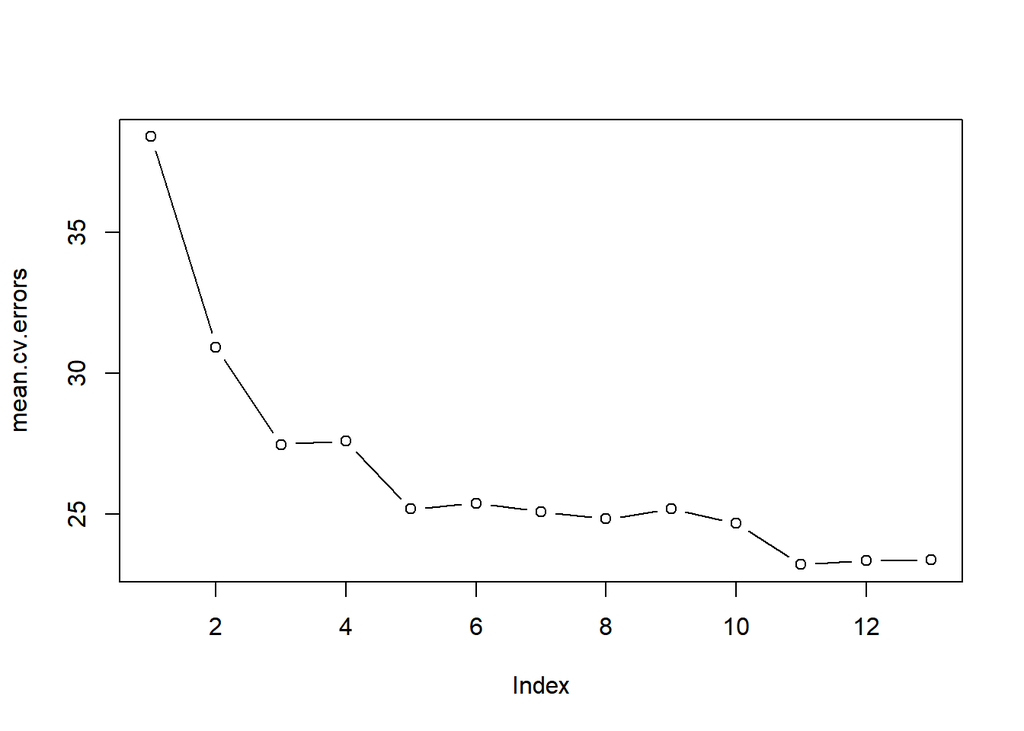

```r
par(mfrow=c(1,1))
plot(mean.cv.errors ,type="b")
```

After doing the CV on the Boston data set we can conclude that the 11 variable model is the best fit.

To get the coefficients for the final model:

```r
bestModel <- regsubsets(medv~., data=Boston, nvmax=13)
coef(bestModel, 11)
```

```
##   (Intercept)          crim            zn          chas           nox
##  36.341145004  -0.108413345   0.045844929   2.718716303 -17.376023429
##            rm           dis           rad           tax       ptratio
##   3.801578840  -1.492711460   0.299608454  -0.011777973  -0.946524570
##         black         lstat
##   0.009290845  -0.522553457
```

## Ridge Regression

Author: Sarah Brown

### Summary/description:

With this method, you shrink the Beta coefficients of your features towards 0. It reduces variance but increases bias in the training data. It doesn’t let you make a coefficient 0 (it shrinks asymptotically) and so no features are fully eliminated. So, we use this when most features are useful and none seem irrelevant (if they did, you’d look at using lasso perhaps). As λ goes up, beta slope goes down and the line gets flatter which means the model is less sensitive to the features. This means that the weight decay in gradient descent is larger.

### When to employ this method/model:

When the the training model is very accurate, but the test model is not, signaling that there is a large least squares error (high variance) in the test model. This means that the line is overfit to the training data. You want to minimize the the cost function which is: RSS + λ * (slope)^2 [penalty] where λ is a tuning parameter that indicates the severity of the penalty. When λ is very high, all coefficients are driven to 0. When λ is equal to 0, there is no effect, so the function is fit with least squares.

Ridge regression often considers the L2 norm, which is the sum of the squares of all coefficients. In particular, it is common to make plots where one axis is equal to the L2 norm with ridge regression divided by the L2 norm with least squares. When this ratio is close to 0, the coefficients with ridge regression take very small values (i.e. λ is very large). When this ratio is 1, the results of ridge regression and least squares are the same (i.e. λ is small).

According to Dr. Chung’s PowerPoint, you can use ridge regression with:

Multiple regression $λ(slope12 + slope22 + \dots)$ (except for intercept)

Categorical X (binary) $Slope = \textit{difference between the two categories}$

Logistic Regression Categorical Y Optimizes sum of likelihoods (rather than RSS)

### Model Code and Inputs:

```r
library(ISLR)
library(glmnet)
data(Hitters)
Hitters <- na.omit(Hitters)
x=model.matrix(Salary~.,Hitters)[,-1]
y=Hitters$Salary

#First, divide the data into training and testing (in this case, its 75% training)
# (6) Create the train (75%) and test (25%) data sets
train = sample(1:nrow(x), nrow(x)*.75)
test=(-train)
y.test=y[test]

#Create a grid of lambda valaues. Then use the glmnet() function to create a model to predict the #training y's using the training x's. Use alpha = 0 for ridge regression.
grid=10^seq(10,-2,length=100)
mod.ridge <- glmnet(x[train,], y[train], alpha=0, lambda =grid)
```

### Model Tests:

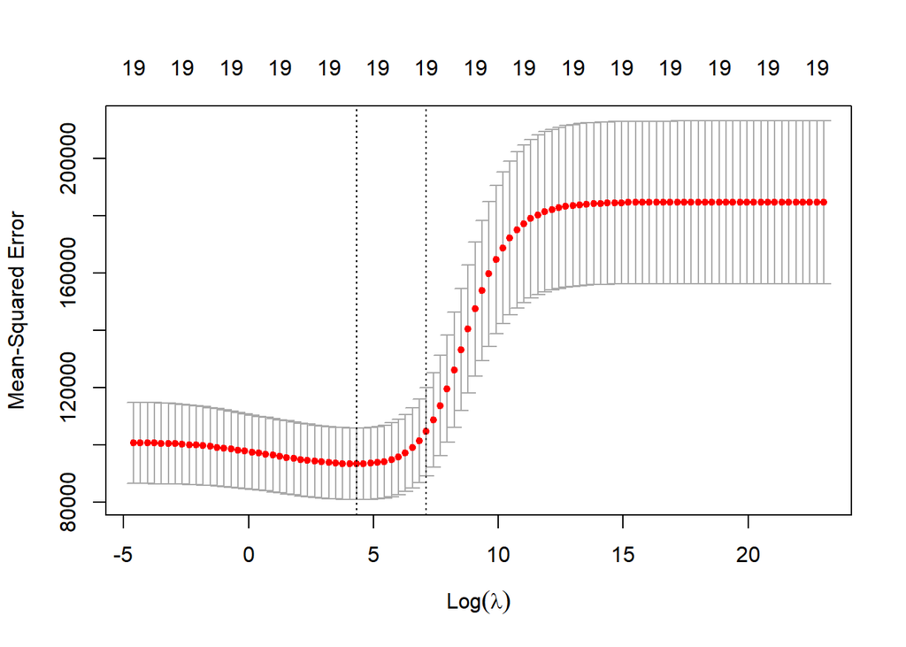

```r
#Evaluate training model performance (how well it predicted the y-values) by using cross-validation, which is the cv.glmnet() function. (In this example code, we are creating a 12-fold cross-validation model, but by default it is a 10-fold cv).
cv.out.ridge <- cv.glmnet(x[train,], y[train], alpha=0, lambda = grid, nfolds = 12)
plot(cv.out.ridge)
```